# heidi

**Distinct Award Levels Offered**

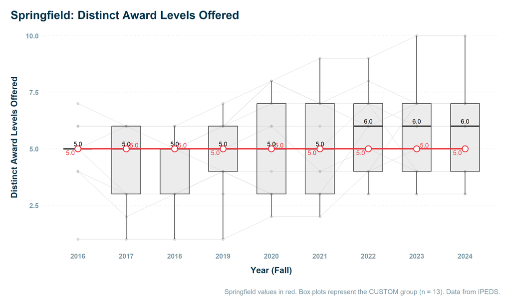

**REVERSE**

**Revenue**

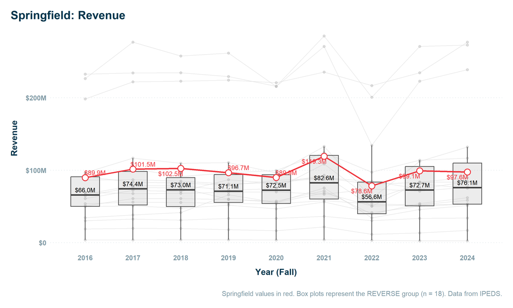

**Expenses**

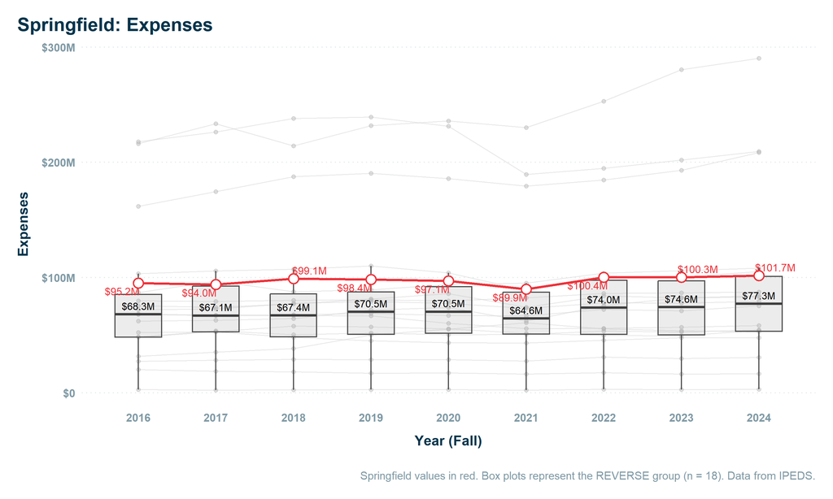

**Margin**

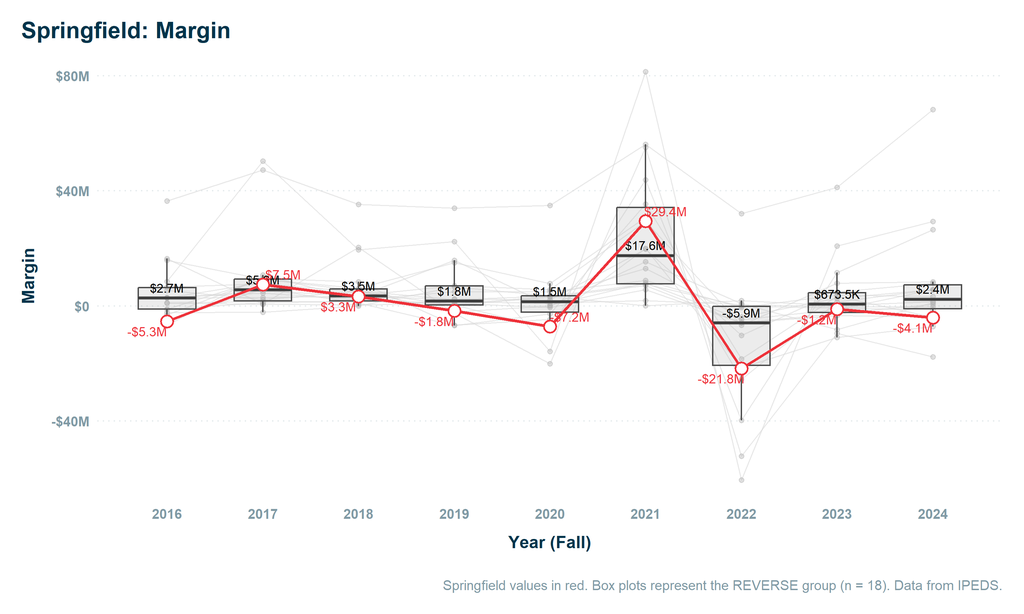

**Endowment**

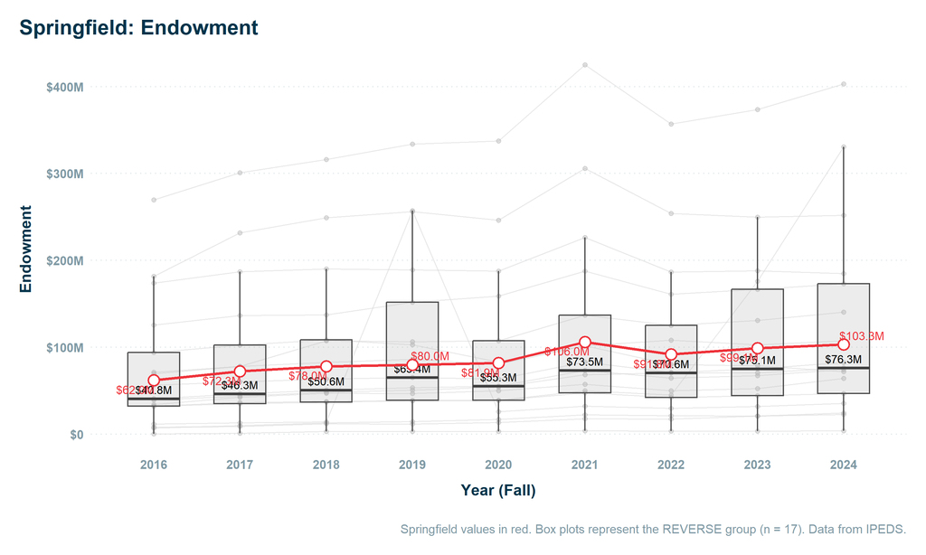

**Avg Net Price**

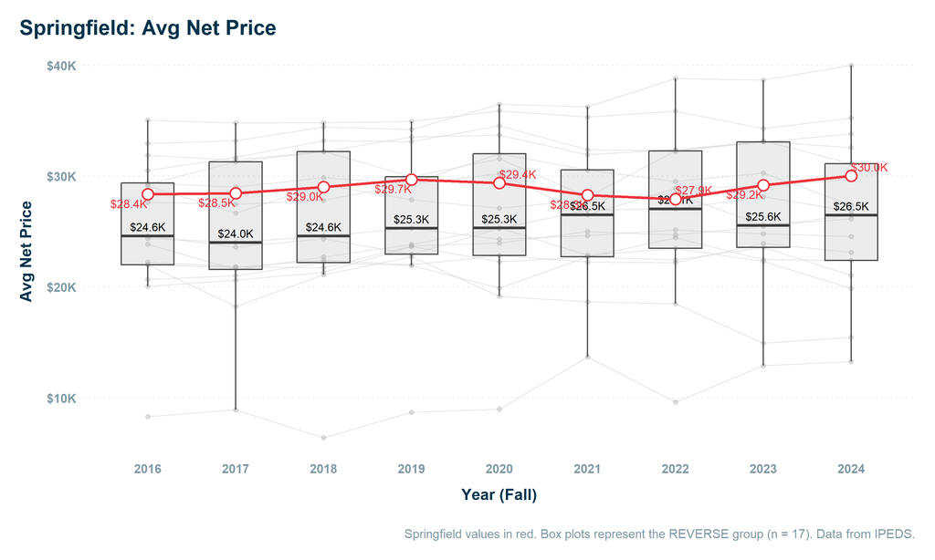

**Avg Net Price + 0.04 * Endowment / UG FTE**

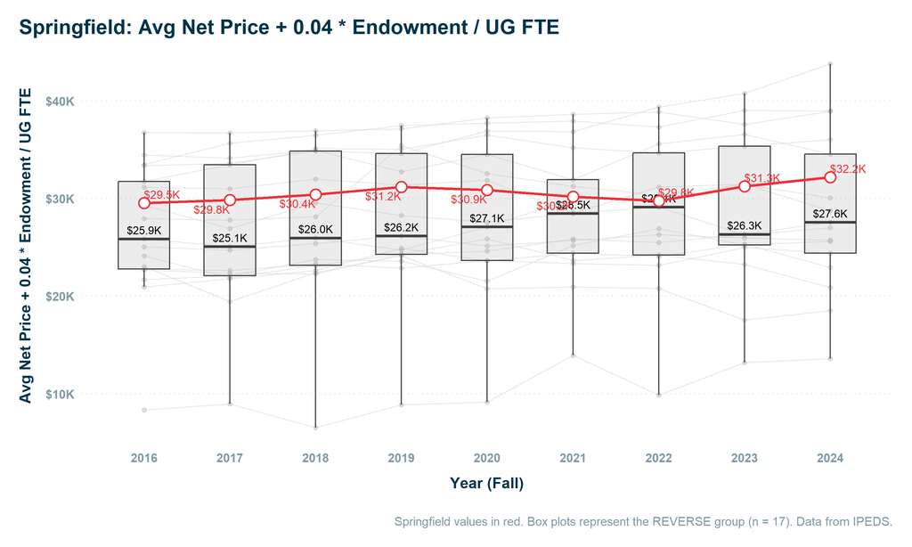

**12-Month Unduplicated Headcount**

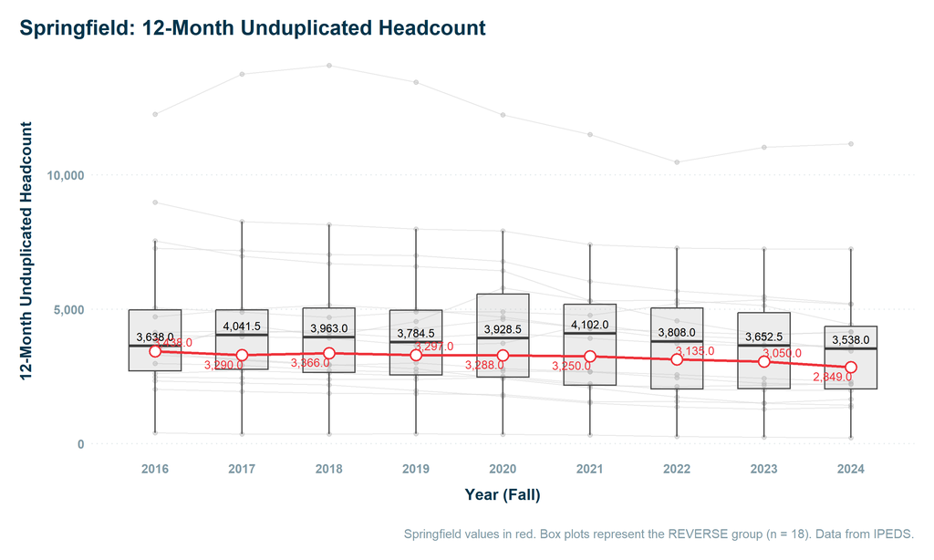

**Undergrad FTE**

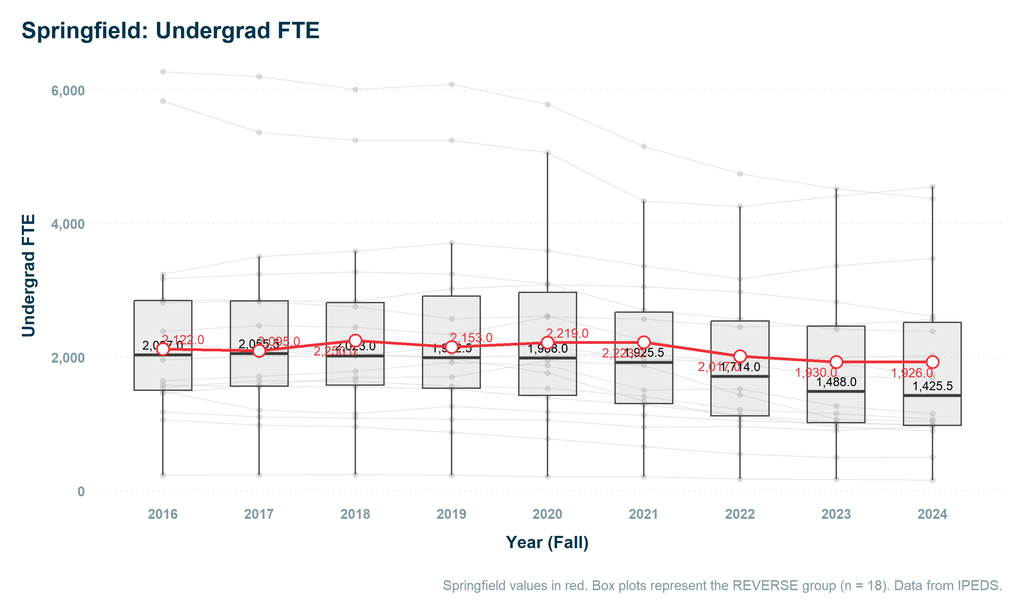

**Grad FTE**

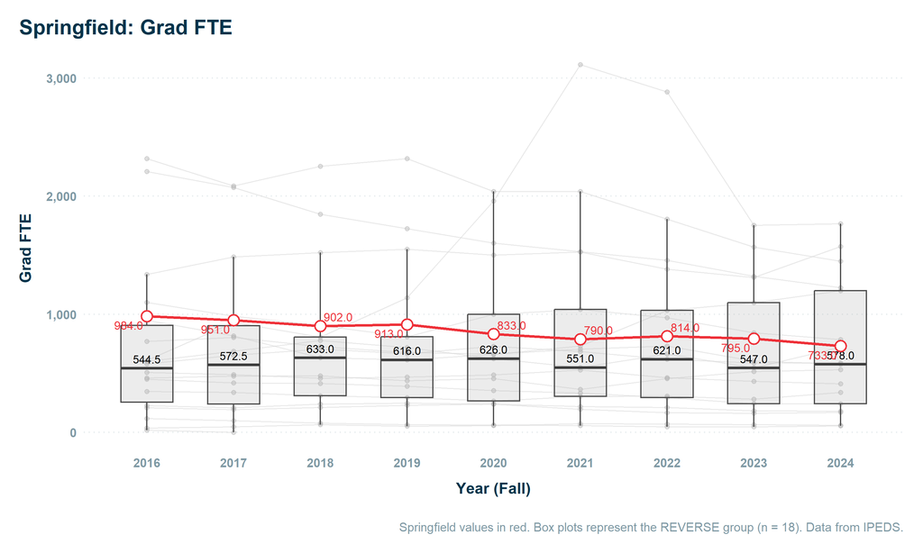

**Doc Prof Prac FTE**

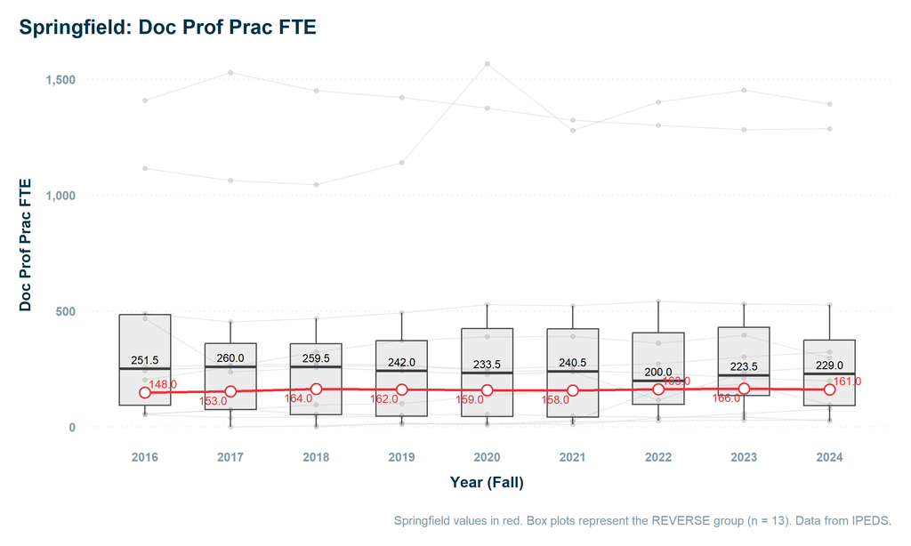

**Total FTE**

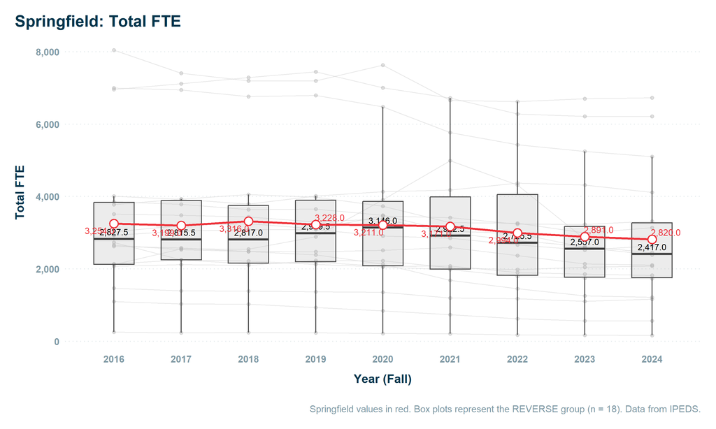

**Student-to-Faculty Ratio**

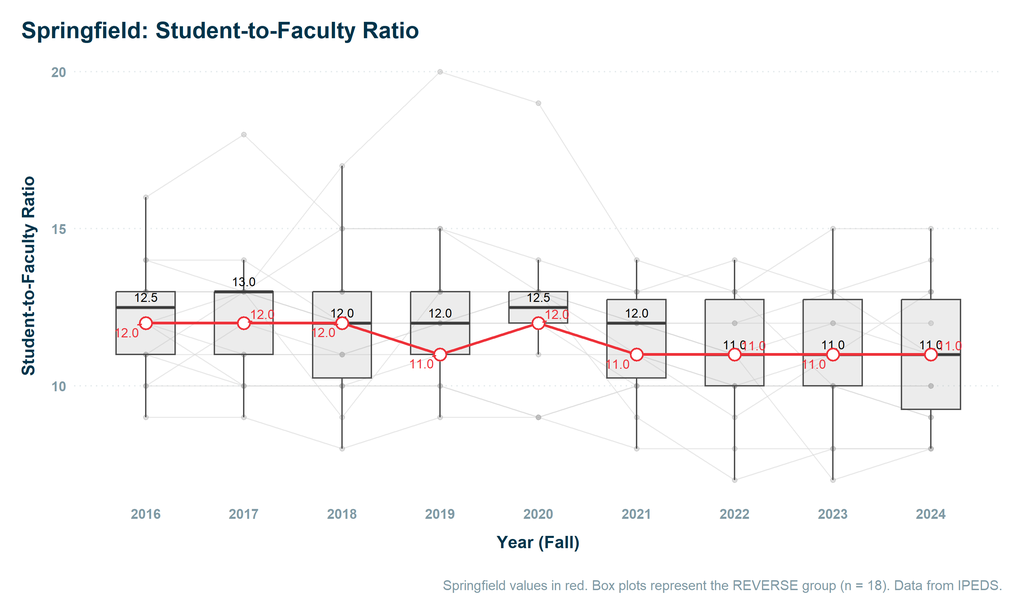

**Undergrad Pell %**

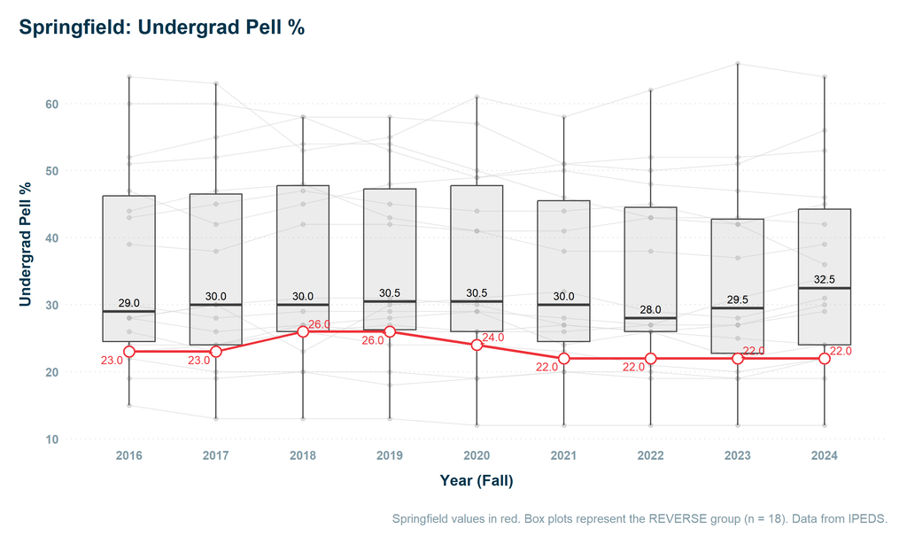

**Program Breadth (distinct 4-digit CIPs)**

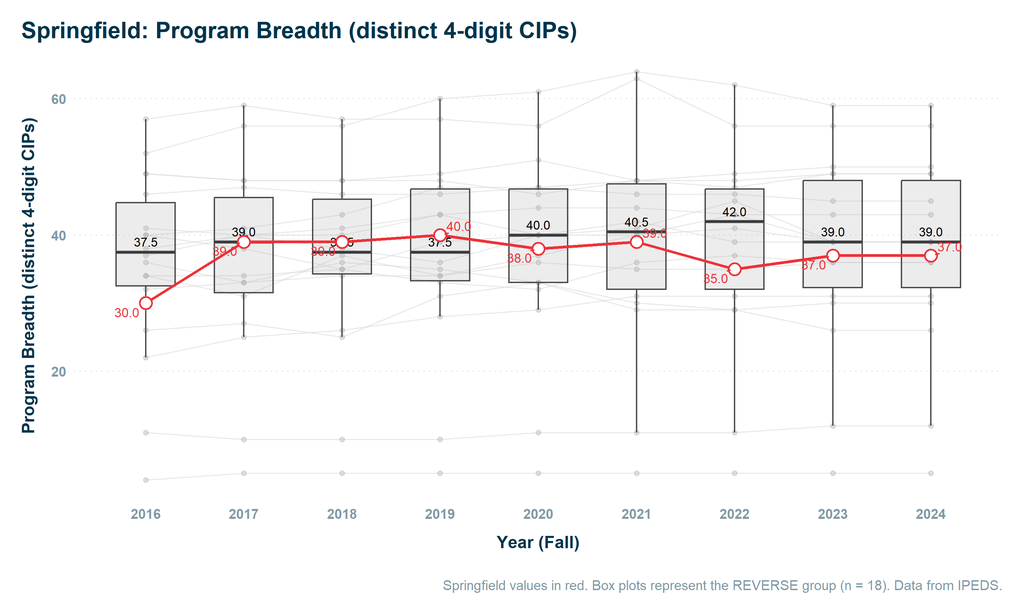

**Top 5 Programs % of Completions**

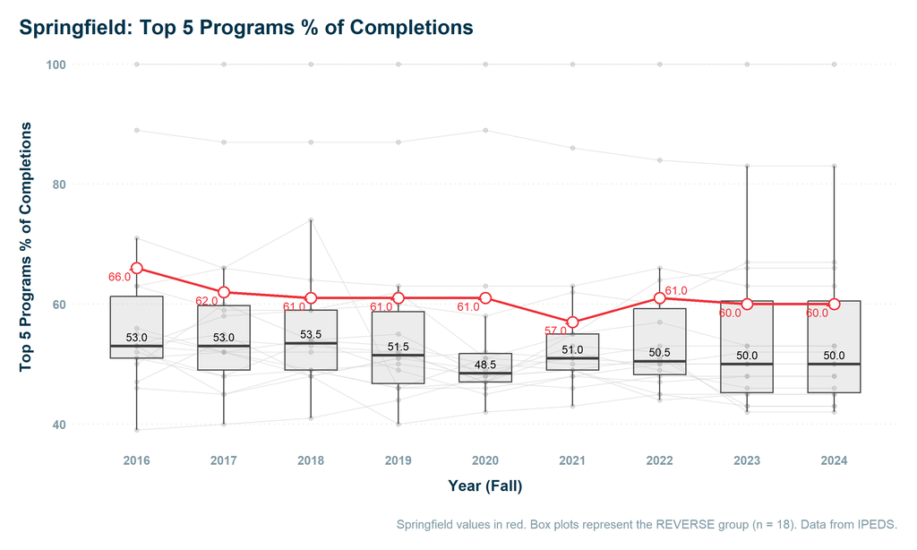

**Distinct Award Levels Offered**

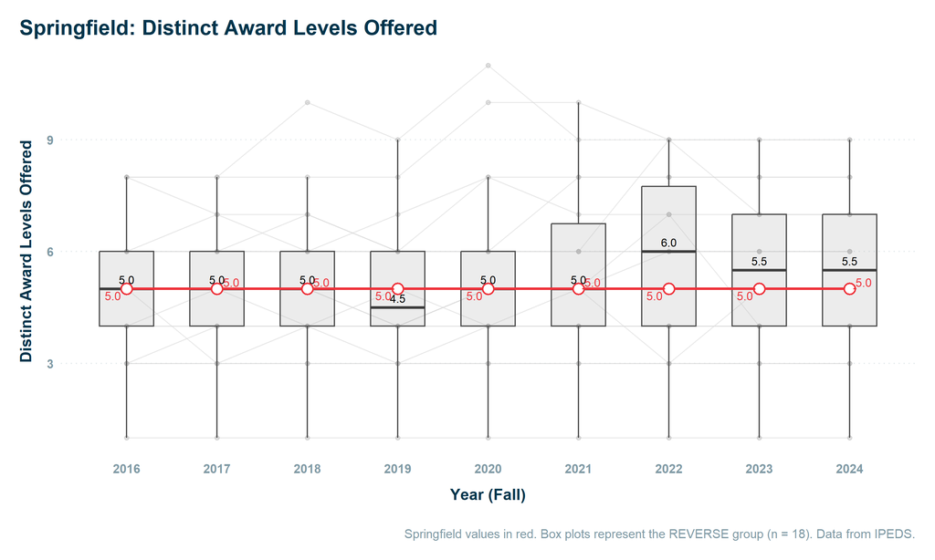

**AUTO**

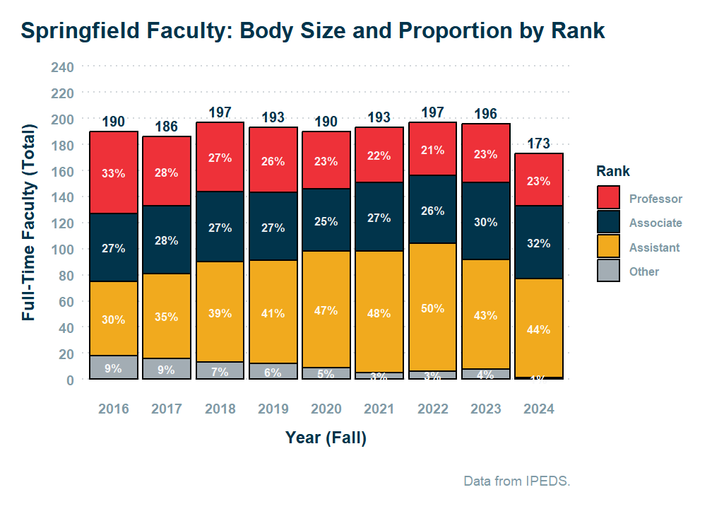

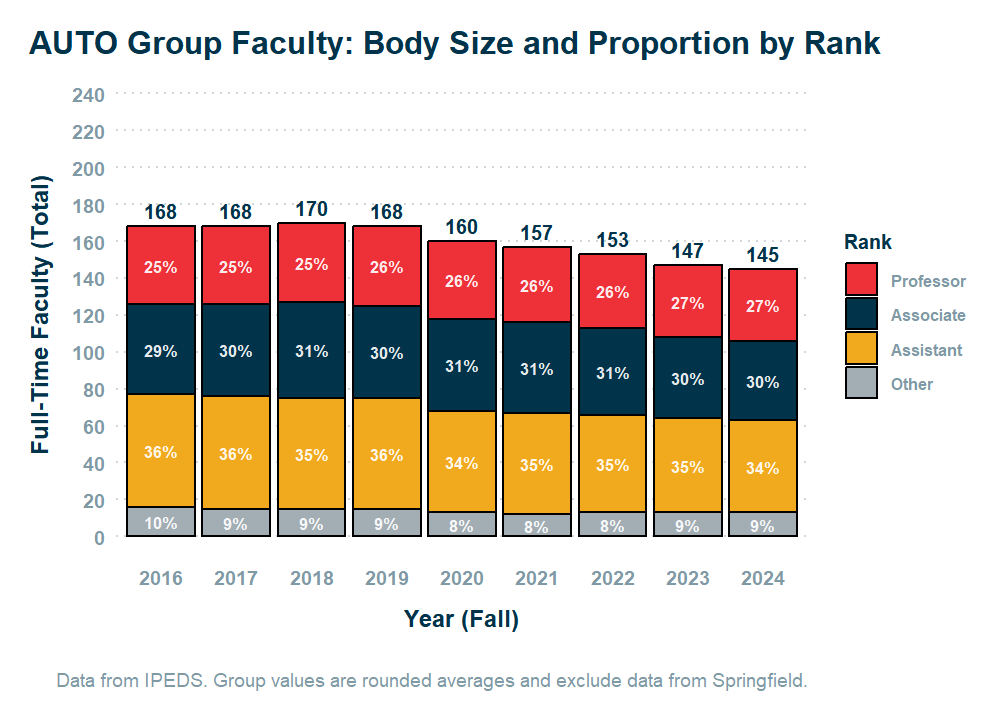

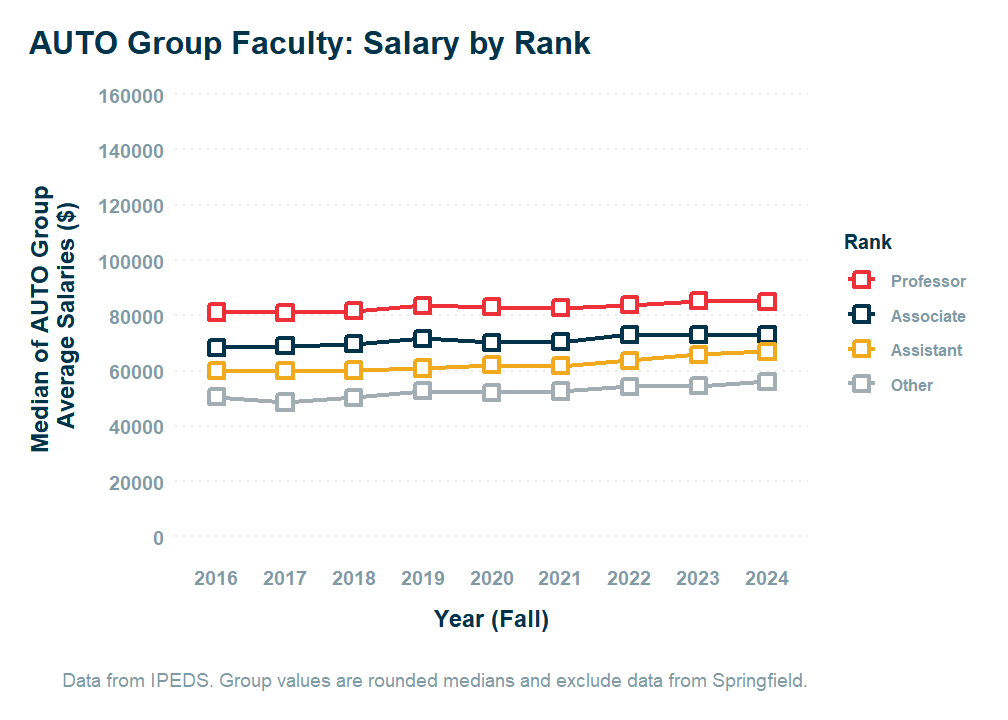

**CUSTOM**

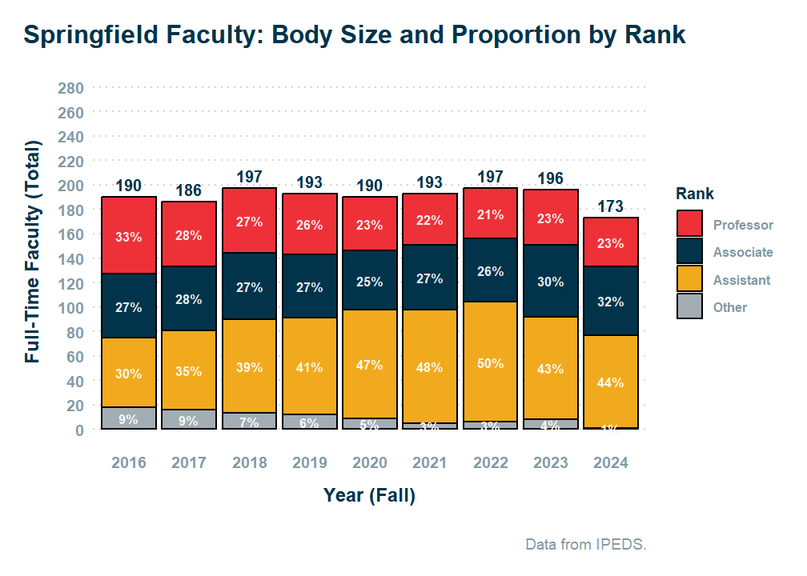

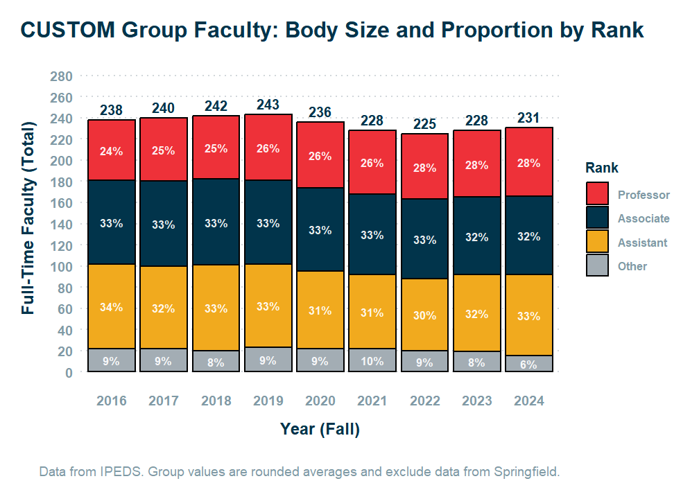

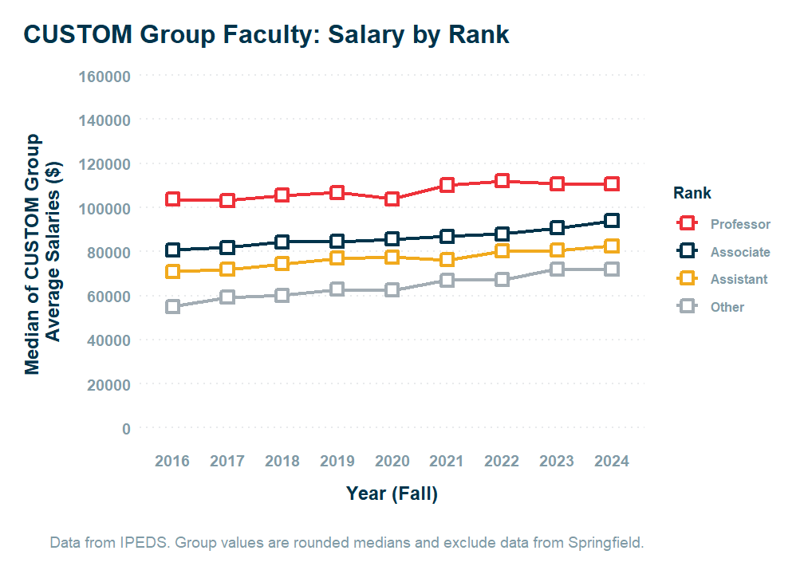

**REVERSE**

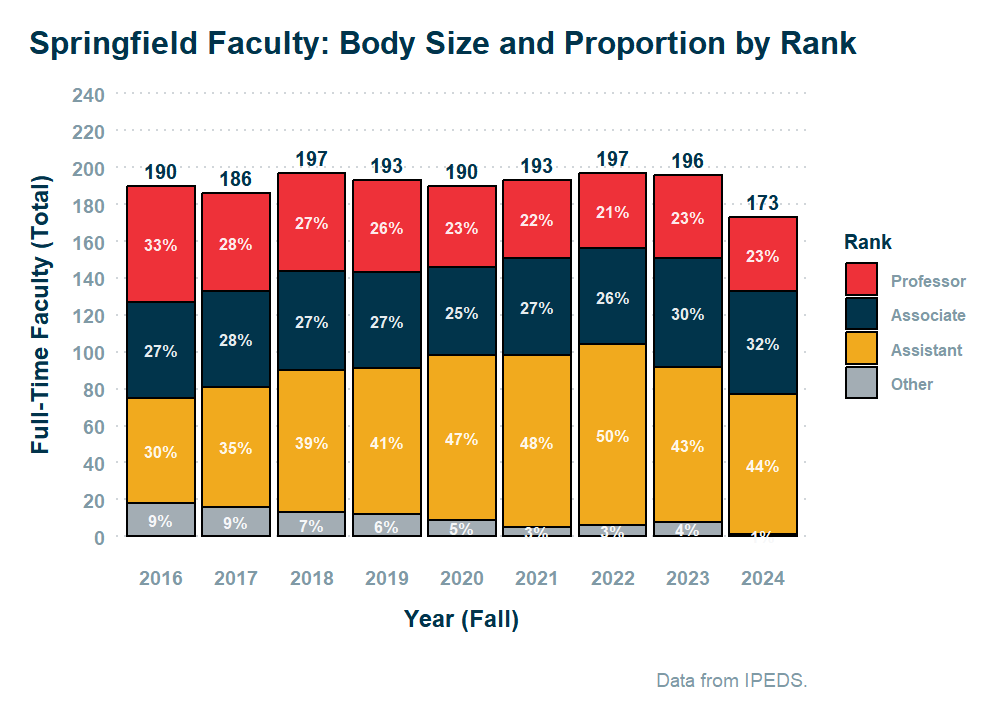

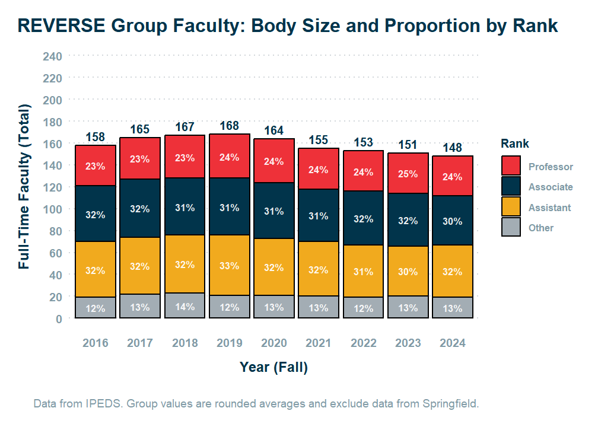

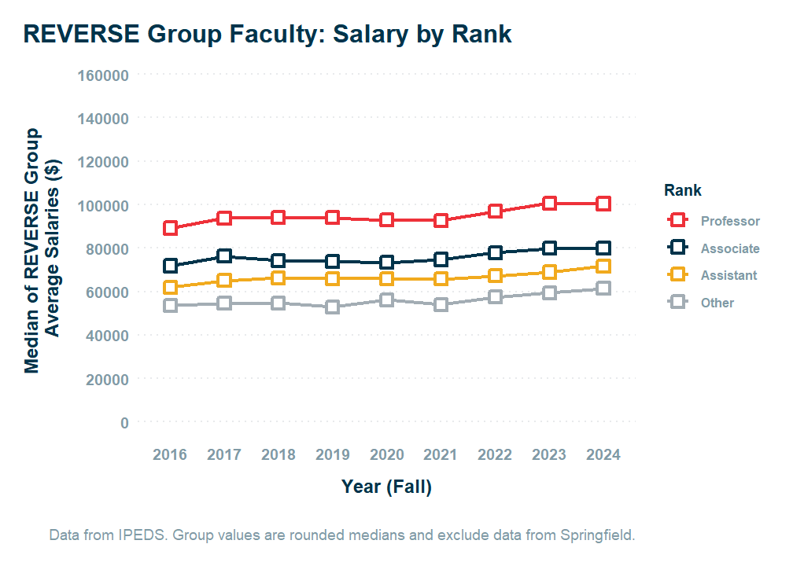

**AUTO**

**Professor Salaries Over Time: AUTO Group**

| Metric | **YEAR (Fall)** 2016 | **YEAR (Fall)** 2017 | **YEAR (Fall)** 2018 | **YEAR (Fall)** 2019 | **YEAR (Fall)** 2020 | **YEAR (Fall)** 2021 | **YEAR (Fall)** 2022 | **YEAR (Fall)** 2023 | **YEAR (Fall)** 2024 | **2016 vs. 2024** CHANGE | **2016 vs. 2024** PERCENT |
| --- | --- | --- | --- | --- | --- | --- | --- | --- | --- | --- | --- |
| min | $51.8k | $52.4k | $49.8k | $49.9k | $48.2k | $50.7k | $57.1k | $56.1k | $58.2k | $6,339 | 12.2% |
| p25 | $73.2k | $74.2k | $71.7k | $76.9k | $75.2k | $76.3k | $78.8k | $78.4k | $80.7k | $7,557 | 10.3% |
| median | $81.2k | $81.2k | $81.6k | $83.6k | $83.2k | $82.7k | $83.9k | $85.2k | $85.1k | $3,876 | 4.8% |
| p75 | $88.9k | $90.3k | $90.2k | $90.6k | $90.8k | $88.4k | $90.0k | $91.2k | $94.3k | $5,458 | 6.1% |
| max | $113.8k | $114.2k | $117.0k | $115.8k | $111.9k | $112.7k | $111.5k | $110.7k | $110.6k | −$3,245 | −2.9% |
| Springfield | $88.2k | $89.0k | $88.5k | $88.9k | $87.6k | $88.1k | $89.9k | $88.1k | $104.5k | $16,303 | 18.5% |
| % of Median | 108.6% | 109.6% | 108.5% | 106.3% | 105.3% | 106.5% | 107.1% | 103.4% | 122.8% |  |  |

Data from IPEDS. Group values exclude data from Springfield.

**Assistant Salaries Over Time: AUTO Group**

| Metric | **YEAR (Fall)** 2016 | **YEAR (Fall)** 2017 | **YEAR (Fall)** 2018 | **YEAR (Fall)** 2019 | **YEAR (Fall)** 2020 | **YEAR (Fall)** 2021 | **YEAR (Fall)** 2022 | **YEAR (Fall)** 2023 | **YEAR (Fall)** 2024 | **2016 vs. 2024** CHANGE | **2016 vs. 2024** PERCENT |
| --- | --- | --- | --- | --- | --- | --- | --- | --- | --- | --- | --- |
| min | $37.2k | $36.8k | $38.2k | $38.2k | $40.2k | $40.3k | $49.0k | $48.2k | $48.4k | $11,197 | 30.1% |
| p25 | $56.1k | $56.8k | $57.9k | $58.7k | $58.2k | $58.0k | $59.1k | $60.8k | $64.2k | $8,170 | 14.6% |
| median | $59.9k | $60.0k | $60.2k | $60.9k | $62.2k | $61.8k | $63.8k | $65.9k | $66.9k | $7,047 | 11.8% |
| p75 | $62.4k | $63.1k | $63.6k | $63.5k | $64.8k | $66.5k | $70.2k | $70.3k | $72.0k | $9,530 | 15.3% |
| max | $76.7k | $76.5k | $74.4k | $75.9k | $74.6k | $76.2k | $80.2k | $87.2k | $87.4k | $10,703 | 14.0% |
| Springfield | $58.5k | $59.6k | $60.7k | $62.5k | $62.2k | $61.5k | $63.4k | $64.7k | $58.7k | $236 | 0.4% |
| % of Median | 97.6% | 99.4% | 100.7% | 102.5% | 100.1% | 99.6% | 99.4% | 98.3% | 87.7% |  |  |

Data from IPEDS. Group values exclude data from Springfield.

**Associate Salaries Over Time: AUTO Group**

| Metric | **YEAR (Fall)** 2016 | **YEAR (Fall)** 2017 | **YEAR (Fall)** 2018 | **YEAR (Fall)** 2019 | **YEAR (Fall)** 2020 | **YEAR (Fall)** 2021 | **YEAR (Fall)** 2022 | **YEAR (Fall)** 2023 | **YEAR (Fall)** 2024 | **2016 vs. 2024** CHANGE | **2016 vs. 2024** PERCENT |
| --- | --- | --- | --- | --- | --- | --- | --- | --- | --- | --- | --- |
| min | $43.7k | $43.9k | $45.1k | $41.9k | $44.0k | $45.7k | $52.2k | $52.4k | $50.2k | $6,503 | 14.9% |
| p25 | $63.1k | $63.5k | $65.6k | $64.9k | $64.9k | $65.0k | $67.0k | $67.5k | $69.5k | $6,453 | 10.2% |
| median | $68.4k | $69.0k | $69.7k | $71.6k | $70.3k | $70.5k | $73.1k | $73.1k | $73.1k | $4,702 | 6.9% |
| p75 | $72.2k | $72.7k | $74.0k | $74.6k | $74.2k | $76.1k | $77.8k | $79.8k | $81.0k | $8,796 | 12.2% |
| max | $83.8k | $84.6k | $84.8k | $85.8k | $83.2k | $85.4k | $86.7k | $90.8k | $91.4k | $7,632 | 9.1% |
| Springfield | $74.7k | $76.1k | $77.1k | $77.2k | $75.7k | $72.6k | $75.0k | $72.6k | $73.6k | −$1,168 | −1.6% |
| % of Median | 109.2% | 110.3% | 110.6% | 107.7% | 107.8% | 103.0% | 102.6% | 99.4% | 100.6% |  |  |

Data from IPEDS. Group values exclude data from Springfield.

**Other Salaries Over Time: AUTO Group**

| Metric | **YEAR (Fall)** 2016 | **YEAR (Fall)** 2017 | **YEAR (Fall)** 2018 | **YEAR (Fall)** 2019 | **YEAR (Fall)** 2020 | **YEAR (Fall)** 2021 | **YEAR (Fall)** 2022 | **YEAR (Fall)** 2023 | **YEAR (Fall)** 2024 | **2016 vs. 2024** CHANGE | **2016 vs. 2024** PERCENT |
| --- | --- | --- | --- | --- | --- | --- | --- | --- | --- | --- | --- |
| min | $30.6k | $29.2k | $21.6k | $16.1k | $17.2k | $28.3k | $30.5k | $31.6k | $32.2k | $1,629 | 5.3% |
| p25 | $46.3k | $44.1k | $45.0k | $47.8k | $47.5k | $47.7k | $48.6k | $50.3k | $49.9k | $3,586 | 7.7% |
| median | $50.6k | $48.6k | $50.4k | $52.7k | $52.1k | $52.6k | $54.3k | $54.5k | $56.1k | $5,568 | 11.0% |
| p75 | $53.9k | $54.1k | $56.0k | $58.3k | $54.1k | $57.1k | $58.9k | $60.1k | $61.2k | $7,300 | 13.5% |
| max | $63.4k | $61.1k | $62.1k | $62.8k | $62.5k | $64.3k | $67.2k | $73.5k | $74.0k | $10,562 | 16.7% |
| Springfield | $50.0k | $51.3k | $52.2k | $52.9k | $54.0k | $56.7k | $56.0k | $50.8k | $51.2k | $1,224 | 2.4% |
| % of Median | 98.9% | 105.5% | 103.5% | 100.5% | 103.6% | 107.7% | 103.2% | 93.3% | 91.3% |  |  |

Data from IPEDS. Group values exclude data from Springfield.

**CUSTOM**

**Professor Salaries Over Time: CUSTOM Group**

| Metric | **YEAR (Fall)** 2016 | **YEAR (Fall)** 2017 | **YEAR (Fall)** 2018 | **YEAR (Fall)** 2019 | **YEAR (Fall)** 2020 | **YEAR (Fall)** 2021 | **YEAR (Fall)** 2022 | **YEAR (Fall)** 2023 | **YEAR (Fall)** 2024 | **2016 vs. 2024** CHANGE | **2016 vs. 2024** PERCENT |
| --- | --- | --- | --- | --- | --- | --- | --- | --- | --- | --- | --- |
| min | $75.9k | $72.1k | $73.4k | $74.6k | $77.0k | $78.1k | $78.6k | $82.6k | $72.9k | −$2,990 | −3.9% |
| p25 | $96.8k | $97.2k | $99.0k | $94.9k | $97.6k | $99.1k | $100.6k | $101.9k | $106.1k | $9,371 | 9.7% |
| median | $103.7k | $103.2k | $105.5k | $106.8k | $103.8k | $110.2k | $112.1k | $110.7k | $110.6k | $6,852 | 6.6% |
| p75 | $110.5k | $109.6k | $112.9k | $113.2k | $116.1k | $117.7k | $122.5k | $125.4k | $127.3k | $16,779 | 15.2% |
| max | $129.2k | $127.9k | $130.6k | $133.2k | $132.3k | $130.9k | $129.4k | $135.3k | $140.5k | $11,341 | 8.8% |
| Springfield | $88.2k | $89.0k | $88.5k | $88.9k | $87.6k | $88.1k | $89.9k | $88.1k | $104.5k | $16,303 | 18.5% |
| % of Median | 85.0% | 86.2% | 83.9% | 83.3% | 84.3% | 79.9% | 80.2% | 79.6% | 94.5% |  |  |

Data from IPEDS. Group values exclude data from Springfield.

**Assistant Salaries Over Time: CUSTOM Group**

| Metric | **YEAR (Fall)** 2016 | **YEAR (Fall)** 2017 | **YEAR (Fall)** 2018 | **YEAR (Fall)** 2019 | **YEAR (Fall)** 2020 | **YEAR (Fall)** 2021 | **YEAR (Fall)** 2022 | **YEAR (Fall)** 2023 | **YEAR (Fall)** 2024 | **2016 vs. 2024** CHANGE | **2016 vs. 2024** PERCENT |
| --- | --- | --- | --- | --- | --- | --- | --- | --- | --- | --- | --- |
| min | $47.5k | $42.9k | $59.7k | $55.9k | $64.9k | $63.6k | $65.8k | $68.1k | $71.4k | $23,839 | 50.2% |
| p25 | $64.1k | $65.9k | $68.8k | $71.6k | $70.7k | $74.1k | $76.8k | $77.8k | $76.5k | $12,398 | 19.3% |
| median | $70.9k | $71.9k | $74.4k | $77.0k | $77.5k | $76.2k | $80.2k | $80.6k | $82.5k | $11,561 | 16.3% |
| p75 | $77.0k | $77.3k | $78.1k | $78.7k | $80.2k | $80.2k | $84.2k | $88.3k | $89.4k | $12,386 | 16.1% |
| max | $85.0k | $86.2k | $86.0k | $86.1k | $86.0k | $86.2k | $85.8k | $90.6k | $95.4k | $10,428 | 12.3% |
| Springfield | $58.5k | $59.6k | $60.7k | $62.5k | $62.2k | $61.5k | $63.4k | $64.7k | $58.7k | $236 | 0.4% |
| % of Median | 82.5% | 82.9% | 81.5% | 81.2% | 80.3% | 80.8% | 79.0% | 80.3% | 71.2% |  |  |

Data from IPEDS. Group values exclude data from Springfield.

**Associate Salaries Over Time: CUSTOM Group**

| Metric | **YEAR (Fall)** 2016 | **YEAR (Fall)** 2017 | **YEAR (Fall)** 2018 | **YEAR (Fall)** 2019 | **YEAR (Fall)** 2020 | **YEAR (Fall)** 2021 | **YEAR (Fall)** 2022 | **YEAR (Fall)** 2023 | **YEAR (Fall)** 2024 | **2016 vs. 2024** CHANGE | **2016 vs. 2024** PERCENT |
| --- | --- | --- | --- | --- | --- | --- | --- | --- | --- | --- | --- |
| min | $50.4k | $62.4k | $63.0k | $68.2k | $65.6k | $67.9k | $71.6k | $71.9k | $64.7k | $14,346 | 28.5% |
| p25 | $77.5k | $79.8k | $81.9k | $82.6k | $79.8k | $82.7k | $85.3k | $85.2k | $88.4k | $10,932 | 14.1% |
| median | $80.8k | $81.9k | $84.3k | $84.5k | $85.6k | $86.9k | $88.1k | $90.8k | $93.9k | $13,118 | 16.2% |
| p75 | $86.9k | $87.6k | $87.6k | $89.7k | $90.3k | $94.4k | $101.0k | $105.6k | $107.5k | $20,536 | 23.6% |
| max | $97.4k | $99.9k | $97.9k | $99.8k | $102.0k | $101.6k | $105.6k | $112.1k | $116.7k | $19,305 | 19.8% |
| Springfield | $74.7k | $76.1k | $77.1k | $77.2k | $75.7k | $72.6k | $75.0k | $72.6k | $73.6k | −$1,168 | −1.6% |
| % of Median | 92.5% | 92.9% | 91.4% | 91.3% | 88.5% | 83.6% | 85.2% | 80.0% | 78.3% |  |  |

Data from IPEDS. Group values exclude data from Springfield.

**Other Salaries Over Time: CUSTOM Group**

| Metric | **YEAR (Fall)** 2016 | **YEAR (Fall)** 2017 | **YEAR (Fall)** 2018 | **YEAR (Fall)** 2019 | **YEAR (Fall)** 2020 | **YEAR (Fall)** 2021 | **YEAR (Fall)** 2022 | **YEAR (Fall)** 2023 | **YEAR (Fall)** 2024 | **2016 vs. 2024** CHANGE | **2016 vs. 2024** PERCENT |
| --- | --- | --- | --- | --- | --- | --- | --- | --- | --- | --- | --- |
| min | $32.3k | $44.7k | $41.8k | $43.1k | $45.9k | $46.8k | $39.1k | $47.9k | $53.0k | $20,698 | 64.1% |
| p25 | $49.8k | $53.8k | $53.8k | $60.6k | $57.8k | $57.2k | $55.4k | $60.7k | $58.8k | $8,947 | 18.0% |
| median | $55.1k | $59.2k | $60.1k | $62.9k | $62.5k | $67.0k | $67.2k | $72.1k | $71.9k | $16,829 | 30.5% |
| p75 | $59.4k | $60.6k | $61.1k | $67.2k | $65.9k | $74.2k | $72.9k | $75.8k | $74.3k | $14,901 | 25.1% |
| max | $64.7k | $73.3k | $75.8k | $79.7k | $82.9k | $80.6k | $88.6k | $82.2k | $82.1k | $17,385 | 26.9% |
| Springfield | $50.0k | $51.3k | $52.2k | $52.9k | $54.0k | $56.7k | $56.0k | $50.8k | $51.2k | $1,224 | 2.4% |
| % of Median | 90.7% | 86.6% | 86.8% | 84.2% | 86.4% | 84.5% | 83.3% | 70.5% | 71.2% |  |  |

Data from IPEDS. Group values exclude data from Springfield.

**REVERSE**

**Professor Salaries Over Time: REVERSE Group**

| Metric | **YEAR (Fall)** 2016 | **YEAR (Fall)** 2017 | **YEAR (Fall)** 2018 | **YEAR (Fall)** 2019 | **YEAR (Fall)** 2020 | **YEAR (Fall)** 2021 | **YEAR (Fall)** 2022 | **YEAR (Fall)** 2023 | **YEAR (Fall)** 2024 | **2016 vs. 2024** CHANGE | **2016 vs. 2024** PERCENT |
| --- | --- | --- | --- | --- | --- | --- | --- | --- | --- | --- | --- |
| min | $57.6k | $56.7k | $58.9k | $64.8k | $60.4k | $58.6k | $52.7k | $66.5k | $68.9k | $11,228 | 19.5% |
| p25 | $77.8k | $77.8k | $78.4k | $79.6k | $74.9k | $77.9k | $82.1k | $80.9k | $86.0k | $8,240 | 10.6% |
| median | $89.2k | $93.7k | $94.1k | $94.0k | $92.9k | $92.7k | $96.9k | $100.6k | $100.4k | $11,200 | 12.6% |
| p75 | $98.0k | $97.2k | $98.9k | $98.7k | $98.5k | $98.8k | $100.6k | $102.3k | $104.4k | $6,435 | 6.6% |
| max | $132.1k | $132.0k | $140.7k | $133.1k | $131.5k | $132.6k | $135.5k | $149.1k | $147.3k | $15,177 | 11.5% |
| Springfield | $88.2k | $89.0k | $88.5k | $88.9k | $87.6k | $88.1k | $89.9k | $88.1k | $104.5k | $16,303 | 18.5% |
| % of Median | 98.9% | 95.0% | 94.0% | 94.6% | 94.2% | 95.0% | 92.8% | 87.6% | 104.1% |  |  |

Data from IPEDS. Group values exclude data from Springfield.

**Assistant Salaries Over Time: REVERSE Group**

| Metric | **YEAR (Fall)** 2016 | **YEAR (Fall)** 2017 | **YEAR (Fall)** 2018 | **YEAR (Fall)** 2019 | **YEAR (Fall)** 2020 | **YEAR (Fall)** 2021 | **YEAR (Fall)** 2022 | **YEAR (Fall)** 2023 | **YEAR (Fall)** 2024 | **2016 vs. 2024** CHANGE | **2016 vs. 2024** PERCENT |
| --- | --- | --- | --- | --- | --- | --- | --- | --- | --- | --- | --- |
| min | $47.1k | $50.1k | $51.6k | $52.5k | $50.5k | $52.6k | $52.3k | $54.6k | $56.8k | $9,695 | 20.6% |
| p25 | $56.7k | $57.5k | $58.7k | $58.1k | $58.3k | $60.7k | $63.6k | $64.4k | $67.9k | $11,166 | 19.7% |
| median | $61.9k | $65.0k | $66.2k | $66.0k | $65.9k | $65.7k | $67.2k | $68.9k | $71.7k | $9,772 | 15.8% |
| p75 | $68.2k | $68.5k | $68.4k | $69.8k | $69.2k | $69.4k | $72.9k | $75.7k | $77.2k | $9,017 | 13.2% |
| max | $107.9k | $107.6k | $101.6k | $102.2k | $106.4k | $101.9k | $101.6k | $109.9k | $106.2k | −$1,702 | −1.6% |
| Springfield | $58.5k | $59.6k | $60.7k | $62.5k | $62.2k | $61.5k | $63.4k | $64.7k | $58.7k | $236 | 0.4% |
| % of Median | 94.5% | 91.7% | 91.6% | 94.7% | 94.4% | 93.6% | 94.4% | 94.0% | 82.0% |  |  |

Data from IPEDS. Group values exclude data from Springfield.

**Associate Salaries Over Time: REVERSE Group**

| Metric | **YEAR (Fall)** 2016 | **YEAR (Fall)** 2017 | **YEAR (Fall)** 2018 | **YEAR (Fall)** 2019 | **YEAR (Fall)** 2020 | **YEAR (Fall)** 2021 | **YEAR (Fall)** 2022 | **YEAR (Fall)** 2023 | **YEAR (Fall)** 2024 | **2016 vs. 2024** CHANGE | **2016 vs. 2024** PERCENT |
| --- | --- | --- | --- | --- | --- | --- | --- | --- | --- | --- | --- |
| min | $48.3k | $50.1k | $51.1k | $56.3k | $57.4k | $56.4k | $60.6k | $61.9k | $62.7k | $14,447 | 29.9% |
| p25 | $62.1k | $66.2k | $63.0k | $68.0k | $65.4k | $68.5k | $69.0k | $72.9k | $72.8k | $10,655 | 17.2% |
| median | $71.8k | $76.2k | $74.2k | $73.8k | $73.3k | $74.7k | $77.9k | $79.9k | $80.0k | $8,243 | 11.5% |
| p75 | $77.6k | $80.8k | $81.7k | $82.6k | $78.9k | $80.2k | $85.3k | $87.8k | $88.5k | $10,982 | 14.2% |
| max | $92.9k | $98.1k | $103.5k | $99.5k | $103.2k | $105.0k | $106.7k | $116.0k | $117.0k | $24,127 | 26.0% |
| Springfield | $74.7k | $76.1k | $77.1k | $77.2k | $75.7k | $72.6k | $75.0k | $72.6k | $73.6k | −$1,168 | −1.6% |
| % of Median | 104.1% | 99.8% | 104.0% | 104.5% | 103.4% | 97.2% | 96.3% | 90.9% | 91.9% |  |  |

Data from IPEDS. Group values exclude data from Springfield.

**Other Salaries Over Time: REVERSE Group**

| Metric | **YEAR (Fall)** 2016 | **YEAR (Fall)** 2017 | **YEAR (Fall)** 2018 | **YEAR (Fall)** 2019 | **YEAR (Fall)** 2020 | **YEAR (Fall)** 2021 | **YEAR (Fall)** 2022 | **YEAR (Fall)** 2023 | **YEAR (Fall)** 2024 | **2016 vs. 2024** CHANGE | **2016 vs. 2024** PERCENT |
| --- | --- | --- | --- | --- | --- | --- | --- | --- | --- | --- | --- |
| min | $29.9k | $29.0k | $25.1k | $25.6k | $21.3k | $31.6k | $35.2k | $39.5k | $37.9k | $8,058 | 27.0% |
| p25 | $41.6k | $45.6k | $46.6k | $47.6k | $50.3k | $48.3k | $50.2k | $54.4k | $55.3k | $13,680 | 32.8% |
| median | $53.6k | $54.6k | $54.7k | $52.8k | $56.1k | $54.0k | $57.4k | $59.5k | $61.4k | $7,825 | 14.6% |
| p75 | $57.9k | $57.9k | $58.8k | $60.7k | $59.8k | $66.8k | $62.6k | $65.9k | $63.3k | $5,486 | 9.5% |
| max | $73.2k | $71.5k | $76.0k | $76.1k | $79.9k | $79.0k | $79.8k | $83.7k | $84.7k | $11,445 | 15.6% |
| Springfield | $50.0k | $51.3k | $52.2k | $52.9k | $54.0k | $56.7k | $56.0k | $50.8k | $51.2k | $1,224 | 2.4% |
| % of Median | 93.3% | 94.0% | 95.3% | 100.2% | 96.2% | 105.0% | 97.5% | 85.5% | 83.4% |  |  |

Data from IPEDS. Group values exclude data from Springfield.

**Top Programs**

**Top 4-Digit Programs — Springfield**

Three-year average graduating class by award level · Data from IPEDS award years 2021-22, 2022-23, 2023-24

| Rank | CIP Code | Program | Avg. Completions/Yr |
| --- | --- | --- | --- |
| Degrees/certificates total |  |  |  |
| 1 | 51.23 | Rehabilitation and Therapeutic Professions. | 168.3 |
| 2 | 31.05 | Sports, Kinesiology, and Physical Education/Fitness. | 120.7 |
| 3 | 44.07 | Social Work. | 92.7 |
| 4 | 51.09 | Allied Health Diagnostic, Intervention, and Treatment Professions. | 83.3 |
| 5 | 13.13 | Teacher Education and Professional Development, Specific Subject Areas. | 42.3 |
| Degrees total |  |  |  |
| 1 | 51.23 | Rehabilitation and Therapeutic Professions. | 168.3 |
| 2 | 31.05 | Sports, Kinesiology, and Physical Education/Fitness. | 120.7 |
| 3 | 44.07 | Social Work. | 92.7 |
| 4 | 51.09 | Allied Health Diagnostic, Intervention, and Treatment Professions. | 83.3 |
| 5 | 13.13 | Teacher Education and Professional Development, Specific Subject Areas. | 42.0 |
| Bachelor's degree |  |  |  |
| 1 | 31.05 | Sports, Kinesiology, and Physical Education/Fitness. | 87.3 |
| 2 | 51.23 | Rehabilitation and Therapeutic Professions. | 78.7 |
| 3 | 51.09 | Allied Health Diagnostic, Intervention, and Treatment Professions. | 51.0 |
| 4 | 51.00 | Health Services/Allied Health/Health Sciences, General. | 41.3 |
| 5 | 42.01 | Psychology, General. | 35.7 |
| Master's degree |  |  |  |
| 1 | 44.07 | Social Work. | 92.7 |
| 2 | 51.23 | Rehabilitation and Therapeutic Professions. | 52.3 |
| 3 | 51.09 | Allied Health Diagnostic, Intervention, and Treatment Professions. | 32.3 |
| 4 | 31.05 | Sports, Kinesiology, and Physical Education/Fitness. | 31.3 |
| 5 | 13.13 | Teacher Education and Professional Development, Specific Subject Areas. | 23.0 |
| Doctor's degree - professional practice |  |  |  |
| 1 | 51.23 | Rehabilitation and Therapeutic Professions. | 37.3 |
| 2 | 42.28 | Clinical, Counseling and Applied Psychology. | 10.3 |
| Doctor's degree - research/scholarship |  |  |  |
| 1 | 13.13 | Teacher Education and Professional Development, Specific Subject Areas. | 2.7 |
| 2 | 26.09 | Physiology, Pathology and Related Sciences. | 2.3 |
| 3 | 31.05 | Sports, Kinesiology, and Physical Education/Fitness. | 2.0 |
| Certificates above the baccalaureate total |  |  |  |
| 1 | 13.10 | Special Education and Teaching. | 2.0 |
| 2 | 13.11 | Student Counseling and Personnel Services. | 1.0 |
| 3 | 42.28 | Clinical, Counseling and Applied Psychology. | 1.0 |
| 4 | 13.13 | Teacher Education and Professional Development, Specific Subject Areas. | 0.3 |
| Post-master's certificate |  |  |  |
| 1 | 13.10 | Special Education and Teaching. | 2.0 |
| 2 | 13.11 | Student Counseling and Personnel Services. | 1.0 |
| 3 | 42.28 | Clinical, Counseling and Applied Psychology. | 1.0 |
| 4 | 13.13 | Teacher Education and Professional Development, Specific Subject Areas. | 0.3 |

*Source: IPEDS Completions survey (C_A), First-major awards at the 4-digit CIP level. Years shown are award years (e.g. “2023-24” = degrees conferred during the 2023-24 academic year, reported to IPEDS in the following collection cycle). “Avg. Completions/Yr” divides the window's total completions by the window length, so a program reporting 30 awards in only one of the three years averages to 10.*

**Award Levels**

**Award Levels Offered — Springfield**

First-major awards over a three-year window (2022-23 through 2024-25) · comparison-group columns show the percent of group members offering the level at least once during the window

| Award Level | **Springfield** Offered | **Springfield** Avg/Yr | **% of Group Offering** AUTO | **% of Group Offering** CUSTOM | **% of Group Offering** REVERSE |
| --- | --- | --- | --- | --- | --- |
| Certificates of less than 12 weeks | — | — | 0.0% | 0.0% | 16.7% |
| Certificates of at least 12 weeks but less than 1 year | — | — | 35.3% | 53.8% | 27.8% |
| Certificates of less than 1 year | — | — | 35.3% | 53.8% | 38.9% |
| Certificates of at least 1 but less than 2 years | — | — | 14.7% | 23.1% | 22.2% |
| Certificates of at least 2 but less than 4 years | — | — | 0.0% | 7.7% | 0.0% |
| Associate's degree | — | — | 52.9% | 53.8% | 44.4% |
| Bachelor's degree | ✓ | 314.0 | 100.0% | 100.0% | 100.0% |
| Postbaccalaureate certificate | — | — | 70.6% | 84.6% | 83.3% |
| Master's degree | ✓ | 219.3 | 100.0% | 100.0% | 94.4% |
| Post-master's certificate | ✓ | 2.0 | 73.5% | 53.8% | 50.0% |
| Doctor's degree - research/scholarship | ✓ | 4.7 | 73.5% | 30.8% | 38.9% |
| Doctor's degree - professional practice | ✓ | 33.0 | 73.5% | 46.2% | 66.7% |
| Doctor's degree - other | — | — | 8.8% | 0.0% | 0.0% |

*Source: IPEDS Completions survey (C_A), First-major awards at the 4-digit CIP level. An institution is counted as offering an award level if it reported at least one completion at that level during the window. “Avg/Yr” is the institution's total completions at the level over the window divided by the window length (3 years), so a level conferred in only one of three years is averaged across all three. Group sizes (excluding the target institution): AUTO n=34 · CUSTOM n=13 · REVERSE n=18.*

**Program Mix**

**Program Mix — Springfield**

Degree programs only (excludes certificates) · First-major awards at 4-digit CIP level

| Program | CIP Code | 2016-17 | 2017-18 | 2018-19 | 2019-20 | 2020-21 | 2021-22 | 2022-23 | 2023-24 |
| --- | --- | --- | --- | --- | --- | --- | --- | --- | --- |
| Rehabilitation and Therapeutic Professions. | 51.23 | 19.0% | 19.9% | 18.8% | 18.8% | 18.0% | 18.0% | 19.8% | 20.6% |
| Sports, Kinesiology, and Physical Education/Fitness. | 31.05 | 14.4% | 10.5% | 12.3% | 11.1% | 12.8% | 13.7% | 13.2% | 14.9% |
| Social Work. | 44.07 | 13.8% | 16.4% | 11.6% | 14.6% | 13.8% | 11.3% | 12.8% | 8.0% |
| Allied Health Diagnostic, Intervention, and Treatment Professions. | 51.09 | 9.9% | 10.2% | 12.6% | 11.4% | 10.8% | 9.0% | 10.3% | 9.5% |
| Teacher Education and Professional Development, Specific Subject Areas. | 13.13 | 6.5% | 5.0% | 5.3% | 5.0% | 4.3% | 3.8% | 3.8% | 6.9% |
| Psychology, General. | 42.01 | 8.4% | 3.0% | 3.0% | 3.9% | 2.8% | 4.1% | 4.2% | 4.1% |
| Health Services/Allied Health/Health Sciences, General. | 51.00 | 1.9% | 2.2% | 3.1% | 4.6% | 5.7% | 4.6% | 5.3% | 4.4% |
| Business Administration, Management and Operations. | 52.02 | 3.9% | 3.9% | 2.0% | 2.9% | 2.9% | 5.1% | 3.2% | 3.3% |

*Values show each program's share (%) of total degree completions in that year. Certificates are excluded. Source: IPEDS Completions survey (C_A), First-major awards. CIP codes are colored by 2-digit family.*

**Similar Peers**

**Institutions with Similar Program Mix to Springfield**

Top 25 by cosine similarity over 4-digit CIP shares · three-year window ending 2024-25

| Rank | Institution | Location | Control | Level | Total FTE | Similarity |
| --- | --- | --- | --- | --- | --- | --- |
| 1 | Emory & Henry University | Emory, VA | Private NFP | 4+ Years | 1,551 | 83.5% |
| 2 | Methodist University | Fayetteville, NC | Private NFP | 4+ Years | 1,727 | 80.0% |
| 3 | Arcadia University | Glenside, PA | Private NFP | 4+ Years | 3,045 | 75.4% |
| 4 | Franklin Pierce University | Rindge, NH | Private NFP | 4+ Years | 1,732 | 70.1% |
| 5 | Hardin-Simmons University | Abilene, TX | Private NFP | 4+ Years | 1,619 | 69.8% |
| 6 | Mount Mary University | Milwaukee, WI | Private NFP | 4+ Years | 1,108 | 69.8% |
| 7 | Saint Ambrose University | Davenport, IA | Private NFP | 4+ Years | 2,467 | 69.4% |
| 8 | College of Saint Mary | Omaha, NE | Private NFP | 4+ Years | 728 | 69.0% |
| 9 | Carroll University | Waukesha, WI | Private NFP | 4+ Years | 3,153 | 68.6% |
| 10 | University of Evansville | Evansville, IN | Private NFP | 4+ Years | 2,059 | 68.1% |
| 11 | Keuka College | Keuka Park, NY | Private NFP | 4+ Years | 1,253 | 67.5% |
| 12 | Wingate University | Wingate, NC | Private NFP | 4+ Years | 3,304 | 67.2% |
| 13 | The University of Montana | Missoula, MT | Public | 4+ Years | 8,444 | 67.0% |
| 14 | University of St. Augustine for Health Sciences | San Marcos, CA | Private For-Profit | 4+ Years | 4,836 | 66.2% |
| 15 | Huntington University | Huntington, IN | Private NFP | 4+ Years | 1,261 | 66.0% |
| 16 | Southwestern College | Santa Fe, NM | Private NFP | 4+ Years | 203 | 66.0% |
| 17 | Rocky Mountain University of Health Professions | Provo, UT | Private For-Profit | 4+ Years | 1,865 | 65.5% |
| 18 | Gannon University | Erie, PA | Private NFP | 4+ Years | 4,113 | 64.7% |
| 19 | Lebanon Valley College | Annville, PA | Private NFP | 4+ Years | 2,081 | 63.3% |
| 20 | Mary Baldwin University | Staunton, VA | Private NFP | 4+ Years | 1,691 | 62.7% |
| 21 | Clarke University | Dubuque, IA | Private NFP | 4+ Years | 890 | 62.7% |
| 22 | University of Indianapolis | Indianapolis, IN | Private NFP | 4+ Years | 4,439 | 62.2% |
| 23 | Hanover College | Hanover, IN | Private NFP | 4+ Years | 1,217 | 61.7% |
| 24 | Alvernia University | Reading, PA | Private NFP | 4+ Years | 2,395 | 61.3% |
| 25 | Rocky Mountain College | Billings, MT | Private NFP | 4+ Years | 971 | 60.9% |

*Cosine similarity measures how closely two institutions' degree program portfolios match. Each institution is represented as a vector of 4-digit CIP shares; the cosine of the angle between two such vectors yields a score from 0 (no overlap) to 100% (identical proportional mix). The calculation excludes certificates and uses First-major awards only, averaged over a three-year window. Institutions with no 4-digit completions in the window are excluded.*

**Program Overlap**

**Program Overlap — Springfield vs. Comparison Groups**

Median 4-digit CIP share (%) across group members for Springfield's top programs (ordered by institution completions, largest first)

| CIP | Program | Springfield | AUTO | CUSTOM | REVERSE |
| --- | --- | --- | --- | --- | --- |
| 51.23 | Rehabilitation and Therapeutic Professions. | 20.2% | 1.9% | 3.3% | 1.5% |
| 31.05 | Sports, Kinesiology, and Physical Education/Fitness. | 14.1% | 1.8% | 0.0% | 0.4% |
| 44.07 | Social Work. | 10.4% | 0.3% | 0.2% | 0.0% |
| 51.09 | Allied Health Diagnostic, Intervention, and Treatment Professions. | 9.9% | 2.1% | 0.1% | 0.0% |
| 13.13 | Teacher Education and Professional Development, Specific Subject Areas. | 5.4% | 0.7% | 1.3% | 0.2% |
| 51.00 | Health Services/Allied Health/Health Sciences, General. | 4.8% | 0.0% | 1.4% | 0.0% |
| 42.01 | Psychology, General. | 4.1% | 3.1% | 4.1% | 3.0% |
| 52.02 | Business Administration, Management and Operations. | 3.3% | 11.0% | 7.1% | 10.3% |
| 42.28 | Clinical, Counseling and Applied Psychology. | 2.7% | 2.0% | 0.2% | 0.4% |
| 51.15 | Mental and Social Health Services and Allied Professions. | 2.6% | 0.0% | 0.0% | 0.0% |
| 43.01 | Criminal Justice and Corrections. | 2.2% | 0.8% | 1.8% | 0.3% |
| 13.11 | Student Counseling and Personnel Services. | 1.8% | 0.0% | 0.0% | 0.0% |
| 26.99 | Biological and Biomedical Sciences, Other. | 1.6% | 0.0% | 0.0% | 0.0% |
| 26.09 | Physiology, Pathology and Related Sciences. | 0.9% | 0.0% | 0.0% | 0.0% |
| 13.10 | Special Education and Teaching. | 0.5% | 0.2% | 1.7% | 0.3% |

*Share values are the median share of total 4-digit CIP completions across group members. Higher values indicate the program is more common in the group.*

**Distinctive Programs**

**Distinctive Programs — Springfield**

Programs where the institution's share differs notably from the comparison group mean (≥1 SD)

| CIP | Program | Direction | Inst. Share | Group Mean | Group SD | Diff (pp) | Z-score |
| --- | --- | --- | --- | --- | --- | --- | --- |
| AUTO |  |  |  |  |  |  |  |
| 26.99 | Biological and Biomedical Sciences, Other. | ▲ Over-represented | 1.6% | 0.0% | 0.1% | 1.5 pp | 10.3 |
| 05.01 | Area Studies. | ▲ Over-represented | 0.6% | 0.0% | 0.1% | 0.6 pp | 6.1 |
| 30.08 | Mathematics and Computer Science. | ▲ Over-represented | 0.5% | 0.0% | 0.1% | 0.4 pp | 4.5 |
| 13.13 | Teacher Education and Professional Development, Specific Subject Areas. | ▲ Over-represented | 5.4% | 1.2% | 1.4% | 4.2 pp | 3.0 |
| 51.23 | Rehabilitation and Therapeutic Professions. | ▲ Over-represented | 20.2% | 4.4% | 5.4% | 15.8 pp | 2.9 |
| 44.07 | Social Work. | ▲ Over-represented | 10.4% | 2.0% | 3.0% | 8.4 pp | 2.8 |
| 31.05 | Sports, Kinesiology, and Physical Education/Fitness. | ▲ Over-represented | 14.1% | 3.4% | 4.7% | 10.6 pp | 2.2 |
| 51.00 | Health Services/Allied Health/Health Sciences, General. | ▲ Over-represented | 4.8% | 1.0% | 2.8% | 3.9 pp | 1.4 |
| 31.03 | Parks, Recreation, and Leisure Facilities Management. | ▲ Over-represented | 0.3% | 0.0% | 0.2% | 0.2 pp | 1.4 |
| 23.01 | English Language and Literature, General. | ▲ Over-represented | 1.2% | 0.6% | 0.4% | 0.5 pp | 1.2 |
| CUSTOM |  |  |  |  |  |  |  |
| 26.99 | Biological and Biomedical Sciences, Other. | ▲ Over-represented | 1.6% | 0.0% | 0.1% | 1.6 pp | 15.8 |
| 05.01 | Area Studies. | ▲ Over-represented | 0.6% | 0.0% | 0.1% | 0.6 pp | 6.3 |
| 30.08 | Mathematics and Computer Science. | ▲ Over-represented | 0.5% | 0.0% | 0.1% | 0.5 pp | 4.7 |
| 51.09 | Allied Health Diagnostic, Intervention, and Treatment Professions. | ▲ Over-represented | 9.9% | 1.4% | 1.9% | 8.6 pp | 4.5 |
| 51.15 | Mental and Social Health Services and Allied Professions. | ▲ Over-represented | 2.6% | 0.5% | 0.7% | 2.2 pp | 3.1 |
| 31.03 | Parks, Recreation, and Leisure Facilities Management. | ▲ Over-represented | 0.3% | 0.0% | 0.1% | 0.3 pp | 2.9 |
| 44.07 | Social Work. | ▲ Over-represented | 10.4% | 1.6% | 3.1% | 8.8 pp | 2.8 |
| 51.23 | Rehabilitation and Therapeutic Professions. | ▲ Over-represented | 20.2% | 4.9% | 5.7% | 15.3 pp | 2.7 |
| 13.13 | Teacher Education and Professional Development, Specific Subject Areas. | ▲ Over-represented | 5.4% | 1.5% | 1.6% | 3.9 pp | 2.5 |
| 24.01 | Liberal Arts and Sciences, General Studies and Humanities. | ▲ Over-represented | 1.5% | 0.4% | 0.4% | 1.0 pp | 2.4 |
| REVERSE |  |  |  |  |  |  |  |
| 31.05 | Sports, Kinesiology, and Physical Education/Fitness. | ▲ Over-represented | 14.1% | 1.3% | 1.7% | 12.8 pp | 7.4 |
| 05.01 | Area Studies. | ▲ Over-represented | 0.6% | 0.0% | 0.1% | 0.6 pp | 6.2 |
| 30.08 | Mathematics and Computer Science. | ▲ Over-represented | 0.5% | 0.0% | 0.1% | 0.5 pp | 4.7 |
| 26.99 | Biological and Biomedical Sciences, Other. | ▲ Over-represented | 1.6% | 0.1% | 0.4% | 1.5 pp | 3.7 |
| 51.09 | Allied Health Diagnostic, Intervention, and Treatment Professions. | ▲ Over-represented | 9.9% | 1.4% | 2.4% | 8.5 pp | 3.5 |
| 51.23 | Rehabilitation and Therapeutic Professions. | ▲ Over-represented | 20.2% | 5.3% | 6.7% | 14.9 pp | 2.2 |
| 44.07 | Social Work. | ▲ Over-represented | 10.4% | 2.0% | 4.0% | 8.4 pp | 2.1 |
| 13.13 | Teacher Education and Professional Development, Specific Subject Areas. | ▲ Over-represented | 5.4% | 1.5% | 2.3% | 3.8 pp | 1.7 |
| 13.11 | Student Counseling and Personnel Services. | ▲ Over-represented | 1.8% | 0.4% | 0.9% | 1.4 pp | 1.5 |
| 51.00 | Health Services/Allied Health/Health Sciences, General. | ▲ Over-represented | 4.8% | 1.6% | 3.2% | 3.3 pp | 1.0 |

*Shares are percentages of total 4-digit First-major completions. Z-score = (institution share – group mean) / group SD. ▲ Over-represented: the program is more prominent at Springfield than typical in the group. ▼ Under-represented: less prominent (including programs the institution does not offer that are common in the comparison group). Only programs with |Z| ≥ 1 are shown (top 10 per group, sorted by z-score descending).*

Each positioning variable included in this dashboard is described below, with its IPEDS source (or derivation formula) and the time frame the value represents.

**A note on IPEDS year labels.** HEART labels every variable by the IPEDS collection cycle in which it was released (e.g., “2024-25”). Different IPEDS surveys inside a single cycle describe different time periods: the Fall Enrollment survey captures that fall’s snapshot, Finance reports the most recent completed fiscal year, and the 12-Month Enrollment and Completions surveys describe the prior academic year. In the 2024-25 release, for example, Completions and 12-month enrollment values describe academic year 2023-24.

### Financial

6 variables

RevenueTOTAL_REVENUE

IPEDS sourceF2 (Finance, FASB) / F2D16

Time frameMost recent fiscal year (FY2024 in the 2024-25 release).

Total revenues and investment return for the fiscal year, as reported in the IPEDS Finance (FASB) survey. Includes tuition and fees, government appropriations and grants, private gifts and contracts, investment return, sales of educational and auxiliary services, hospital revenue, independent operations, and other revenue. HEART uses the FASB (private not-for-profit or public using FASB) version of the Finance table.

IPEDS variable title: *Total revenues and investment return - Total* · Table: *Private not-for-profit institutions or Public institutions using FASB: Fiscal year 2024*

ExpensesEXPENSES

IPEDS sourceF2 (Finance, FASB) / F2E131

Time frameMost recent fiscal year (FY2024 in the 2024-25 release).

Total expenses for the fiscal year across all functional categories (instruction, research, public service, academic support, student services, institutional support, auxiliary enterprises, etc.).

IPEDS variable title: *Total expenses-Total amount* · Table: *Private not-for-profit institutions or Public institutions using FASB: Fiscal year 2024*

MarginMARGIN

IPEDS sourceDerived

Time frameMost recent fiscal year (FY2024 in the 2024-25 release).

Operating margin for the fiscal year, computed as TOTAL_REVENUE minus EXPENSES. Negative values indicate the institution spent more than it took in. Not adjusted for investment return, depreciation, or unrealized gains/losses beyond what IPEDS already includes in its revenue and expense totals.

EndowmentENDOWMENT

IPEDS sourceF2 (Finance, FASB) / F2H02

Time frameEnd-of-fiscal-year snapshot (FY2024 in the 2024-25 release).

Value of endowment assets at the end of the fiscal year. Includes gross investments of endowment funds, term endowment funds, and funds functioning as endowment for the institution and its affiliated foundations. Reported per the IPEDS Finance (FASB) survey.

IPEDS variable title: *Value of endowment assets at the end of the fiscal year* · Table: *Private not-for-profit institutions or Public institutions using FASB: Fiscal year 2024*

Avg Net PriceAVG_NET_PRICE

IPEDS sourceCOST2 (Student Financial Aid) / NPGRN2

Time frameAcademic year 2023-24 in the 2024-25 release. Grant-aid based net price only.

Average net price for full-time, first-time, degree/certificate-seeking undergraduates who were awarded grant or scholarship aid from federal, state or local governments, or the institution. Other grant sources are excluded. Computed by IPEDS as total cost of attendance minus average grant/scholarship aid.

IPEDS variable title: *Average net price-students awarded grant or scholarship aid, 2023-24* · Table: *COST2_2024_netprice*

Avg Net Price + 0.04 * Endowment / UG FTEMODIFIED_PRICE

IPEDS sourceDerived

Time frameCombines the 2023-24 net price with 4% of FY2024 endowment per UG FTE.

A HEART-specific adjusted net price that captures how much of an institution’s published net price is effectively subsidized by endowment income. Formula: AVG_NET_PRICE + 0.04 * (ENDOWMENT / FTE_UG). Uses a 4% spending rate on endowment per UG FTE as a proxy for sustainable endowment contribution. The coefficient is set by `endow_percent` in options_and_misc.R.

### Size

5 variables

12-Month Unduplicated HeadcountHEADCOUNT_TOTAL

IPEDS sourceDRVEF12 (12-Month Enrollment, derived) / UNDUP

Time frameAcademic year 2023-24 in the 2024-25 release (12-month unduplicated count).

Total 12-month unduplicated headcount: the number of distinct students the institution served at any point during the 12-month reporting period. Each student is counted once regardless of when they enrolled or how many terms they attended.

IPEDS variable title: *Total 12-month unduplicated headcount* · Table: *Frequently used derived variables (E12): 12-month enrollment, 2023-24*

Undergrad FTEFTE_UG

IPEDS sourceEFIA (12-Month Instructional Activity) / FTEUG

Time frameAcademic year 2023-24 in the 2024-25 release.

Reported full-time-equivalent undergraduate enrollment for the 12-month period, from the IPEDS 12-Month Instructional Activity component. NCES uses this value to calculate per-FTE expenses and revenues in the IPEDS Data Feedback Report.

IPEDS variable title: *Reported full-time equivalent (FTE) undergraduate enrollment, 2023-24* · Table: *12-month instructional activity: 2023-24*

Grad FTEFTE_GRAD

IPEDS sourceEFIA (12-Month Instructional Activity) / FTEGD

Time frameAcademic year 2023-24 in the 2024-25 release.

Reported full-time-equivalent graduate enrollment for the 12-month period, from the IPEDS 12-Month Instructional Activity component.

IPEDS variable title: *Reported full-time equivalent (FTE) graduate enrollment, 2023-24* · Table: *12-month instructional activity: 2023-24*

Doc Prof Prac FTEFTE_DOC

IPEDS sourceEFIA (12-Month Instructional Activity) / FTEDPP

Time frameAcademic year 2023-24 in the 2024-25 release.

Reported full-time-equivalent enrollment for doctor’s professional-practice programs (e.g., MD, JD, DDS, DVM, PharmD) over the 12-month period. Captured separately from FTE_GRAD because these programs have distinct award levels and credit-hour structures.

IPEDS variable title: *Reported full-time equivalent (FTE) doctors professional practice, 2023-24* · Table: *12-month instructional activity: 2023-24*

Total FTEFTE_TOTAL

IPEDS sourceDRVEF12 (12-Month Enrollment, derived) / FTE12MN

Time frameAcademic year 2023-24 in the 2024-25 release.

12-month full-time-equivalent total enrollment: the sum of FTE_UG, FTE_GRAD, and FTE_DOC. When IPEDS does not report FTE12MN directly, HEART computes it as the sum of the three component values.

IPEDS variable title: *12-month full-time equivalent enrollment* · Table: *Frequently used derived variables (E12): 12-month enrollment, 2023-24*

### Student

2 variables

Student-to-Faculty RatioSTU_FAC_RATIO

IPEDS sourceEF_D (Fall Enrollment) / STUFACR

Time frameFall 2024 snapshot (Fall enrollment component of the 2024-25 collection).

Student-to-faculty ratio: total FTE students not in graduate or professional programs divided by total FTE instructional staff not teaching in graduate or professional programs. FTE students is full-time students plus one-third of part-time students. Reported in the Fall Enrollment survey.

IPEDS variable title: *Student-to-faculty ratio* · Table: *Total entering class, retention rates, and student-to-faculty ratio: Fall 2024*

Undergrad Pell %UG_PELL_PERCENT

IPEDS sourceSFA (Student Financial Aid) / UPGRNTP

Time frameAcademic year 2023-24 in the 2024-25 release.

Percent of undergraduate students awarded Federal Pell Grant aid during the academic year. Pell Grants provide need-based aid to eligible undergraduates under Title IV, Part A. Reported in the Student Financial Aid survey.

IPEDS variable title: *Percent of undergraduate students awarded Federal Pell grants* · Table: *Student financial aid: 2023-24*

### Academic Portfolio

3 variables

Program Breadth (distinct 4-digit CIPs)CIP_BREADTH_4D

IPEDS sourceDerived from C_A (Completions)

Time frameAcademic year 2023-24 in the 2024-25 release.

Count of distinct 4-digit CIP codes in which the institution had any First-major completions during the academic year, excluding the CIP 99 grand-total row. Measures the breadth of the institution’s academic portfolio. The “4D” in the name refers to CIP depth (4-digit taxonomy level), not a numeric range. Derived from the IPEDS Completions (C_A) table.

Top 5 Programs % of CompletionsTOP5_CIP_SHARE

IPEDS sourceDerived from C_A (Completions)

Time frameAcademic year 2023-24 in the 2024-25 release.

Percent of First-major completions concentrated in the top five 4-digit CIP codes during the academic year. A complementary view of concentration: 100% means fewer than six programs account for all completions, while lower values indicate completions are spread across more programs. Derived from the IPEDS Completions (C_A) table.

Distinct Award Levels OfferedAWARD_LEVEL_COUNT

IPEDS sourceDerived from C_A (Completions)

Time frameAcademic year 2023-24 in the 2024-25 release.

Number of distinct award levels (e.g., certificate, associate’s, bachelor’s, master’s, doctoral) in which the institution had any First-major completions during the academic year. A rough indicator of how many degree tiers the institution actively produces. IPEDS rollup totals (Degrees total, Certificates below the baccalaureate level total, Certificates above the baccalaureate total, Degrees/certificates total) are excluded so the count reflects credential tiers offered rather than IPEDS-computed subtotals; the theoretical maximum is 13. Derived from the IPEDS Completions (C_A) table.